# Multinomial

Coreys Notes

There are several ways to perform multiclass classification in R. Here are three approaches you can try:

One-versus-all (OvA) method: This method involves training a separate binary classifier for each class, where the class is treated as the positive case and all other classes are treated as the negative case. At prediction time, you would run the input through each classifier and select the class that is predicted with the highest probability.

One-versus-one (OvO) method: This method involves training a binary classifier for every pair of classes. For example, if you have three classes, you would train three classifiers: one to distinguish between class 1 and class 2, one to distinguish between class 1 and class 3, and one to distinguish between class 2 and class 3. At prediction time, you would run the input through all the classifiers and use a voting system to determine the final class label.

Multinomial logistic regression: This method involves training a single logistic regression model with multiple output units, one for each class. The model would be trained to predict the probability of each class for a given input. At prediction time, you would select the class with the highest predicted probability.

# 1 GBM multiclass

```r
library(gbm)
library(caret)
data(iris)
fitControl <- trainControl(method="cv",
                           number=10,
                           verboseIter=TRUE)
set.seed(825)
gbmFit <- train(Species ~ ., data=iris,
                method="gbm",
                trControl=fitControl,
                verbose=FALSE)
gbmFit
```

```
## Stochastic Gradient Boosting
##
## 150 samples
##   4 predictor
##   3 classes: 'setosa', 'versicolor', 'virginica'
##
## No pre-processing
## Resampling: Cross-Validated (10 fold)
## Summary of sample sizes: 135, 135, 135, 135, 135, 135, ...
## Resampling results across tuning parameters:
##
##   interaction.depth  n.trees  Accuracy   Kappa
##   1                   50      0.9533333  0.93
##   1                  100      0.9400000  0.91
##   1                  150      0.9333333  0.90
##   2                   50      0.9466667  0.92
##   2                  100      0.9400000  0.91
##   2                  150      0.9400000  0.91
##   3                   50      0.9466667  0.92
##   3                  100      0.9400000  0.91
##   3                  150      0.9333333  0.90
##
## Tuning parameter 'shrinkage' was held constant at a value of 0.1
##
## Tuning parameter 'n.minobsinnode' was held constant at a value of 10
## Accuracy was used to select the optimal model using the largest value.
## The final values used for the model were n.trees = 50, interaction.depth =
##  1, shrinkage = 0.1 and n.minobsinnode = 10.
```

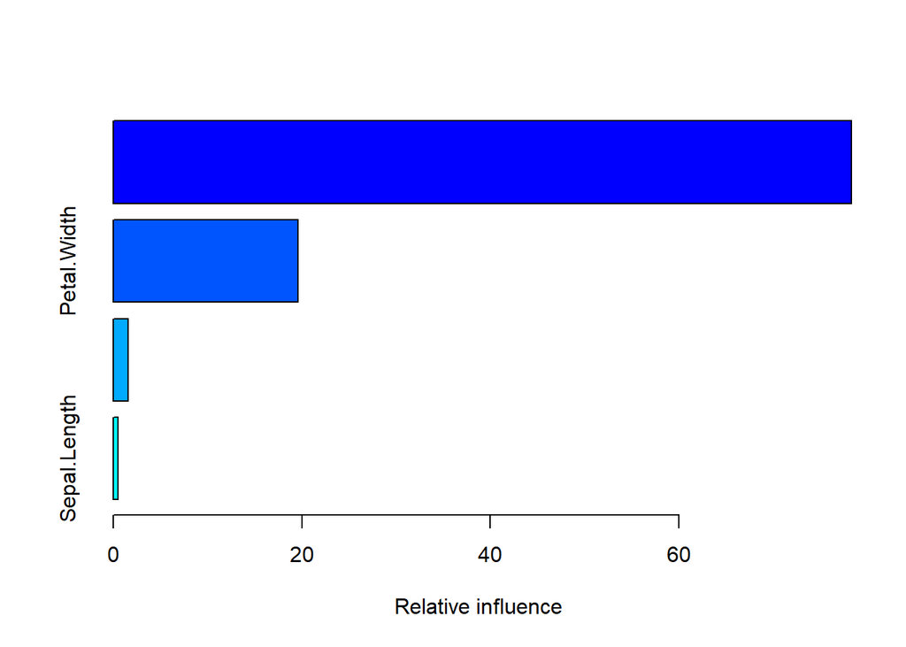

```
##                       var    rel.inf
## Petal.Length Petal.Length 78.2998269
## Petal.Width   Petal.Width 19.6133605
## Sepal.Width   Sepal.Width  1.6093473
## Sepal.Length Sepal.Length  0.4774653
```

```r
summary(gbmFit)
```

```r
head(predict(gbmFit,iris,type="prob"))
```

```
##      setosa  versicolor    virginica
## 1 0.9963368 0.003585358 7.779232e-05
## 2 0.9976247 0.002297416 7.789287e-05
## 3 0.9976247 0.002297416 7.789287e-05
## 4 0.9976247 0.002297416 7.789287e-05
## 5 0.9963368 0.003585358 7.779232e-05
## 6 0.9963368 0.003585358 7.779232e-05
```

```r
gbm.pred <- predict(gbmFit,iris,type="raw")
head(gbm.pred)
```

```
## [1] setosa setosa setosa setosa setosa setosa
## Levels: setosa versicolor virginica
```

```r
confusionMatrix(gbm.pred, iris$Species)
```

```
## Confusion Matrix and Statistics
##
##             Reference
## Prediction   setosa versicolor virginica
##   setosa         50          0         0
##   versicolor      0         49         1
##   virginica       0          1        49
##
## Overall Statistics
##
##                Accuracy : 0.9867
##                  95% CI : (0.9527, 0.9984)
##     No Information Rate : 0.3333
##     P-Value [Acc > NIR] : < 2.2e-16
##
##                   Kappa : 0.98
##
##  Mcnemar's Test P-Value : NA
##
## Statistics by Class:
##
##                      Class: setosa Class: versicolor Class: virginica
## Sensitivity                 1.0000            0.9800           0.9800
## Specificity                 1.0000            0.9900           0.9900
## Pos Pred Value              1.0000            0.9800           0.9800
## Neg Pred Value              1.0000            0.9900           0.9900
## Prevalence                  0.3333            0.3333           0.3333
## Detection Rate              0.3333            0.3267           0.3267
## Detection Prevalence        0.3333            0.3333           0.3333
## Balanced Accuracy           1.0000            0.9850           0.9850
```

# 2 Multinomial Logistic Regression

$ln\left(\frac{P(y=group2)}{P(y=group1)}\right)$=$\beta_{0}+\beta_{1}x_{1}...$

$ln\left(\frac{P(y=group3)}{P(y=group1)}\right)$=$\beta'_{0}+\beta'_{1}x_{1}...$

```r
library(nnet)
library(caret)
```

```r
mydf <- iris

myMod <- multinom(Species~.,data=mydf)
myMod
```

```
## Call:
## multinom(formula = Species ~ ., data = mydf)
##
## Coefficients:
##            (Intercept) Sepal.Length Sepal.Width Petal.Length Petal.Width
## versicolor    18.69037    -5.458424   -8.707401     14.24477   -3.097684
## virginica    -23.83628    -7.923634  -15.370769     23.65978   15.135301
##
## Residual Deviance: 11.89973
## AIC: 31.89973
```

```r
fit.control <- trainControl(method = "cv", number = 10)

set.seed(123)
fit <- train(Species ~., data = iris, method = "multinom", trControl = fit.control, trace = FALSE)

fit
```

```
## Penalized Multinomial Regression
##
## 150 samples
##   4 predictor
##   3 classes: 'setosa', 'versicolor', 'virginica'
##
## No pre-processing
## Resampling: Cross-Validated (10 fold)
## Summary of sample sizes: 135, 135, 135, 135, 135, 135, ...
## Resampling results across tuning parameters:
##
##   decay  Accuracy   Kappa
##   0e+00  0.9800000  0.97
##   1e-04  0.9800000  0.97
##   1e-01  0.9666667  0.95
##
## Accuracy was used to select the optimal model using the largest value.
## The final value used for the model was decay = 1e-04.
```

```r
confusionMatrix(fit)
```

```
## Cross-Validated (10 fold) Confusion Matrix
##
## (entries are percentual average cell counts across resamples)
##
##             Reference
## Prediction   setosa versicolor virginica
##   setosa       33.3        0.0       0.0
##   versicolor    0.0       32.0       0.7
##   virginica     0.0        1.3      32.7
##
##  Accuracy (average) : 0.98
```

# 3 Classification Tree

```r
library(rpart)
library(rpart.plot)
```

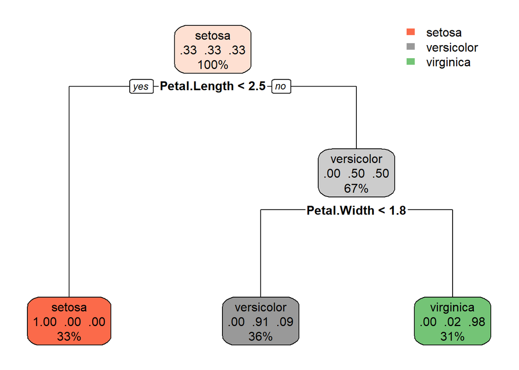

```r
mytree <- rpart(Species ~ ., data = iris)
rpart.plot(mytree)
```

```r
set.seed(123)
classificationTreeTrain <- train(Species ~ ., data = iris, method = "rpart", trControl = trainControl(method="cv",number=10))
classificationTreeTrain
```

```
## CART
##
## 150 samples
##   4 predictor
##   3 classes: 'setosa', 'versicolor', 'virginica'
##
## No pre-processing
## Resampling: Cross-Validated (10 fold)
## Summary of sample sizes: 135, 135, 135, 135, 135, 135, ...
## Resampling results across tuning parameters:
##
##   cp    Accuracy   Kappa
##   0.00  0.9400000  0.91
##   0.44  0.7533333  0.63
##   0.50  0.3333333  0.00
##
## Accuracy was used to select the optimal model using the largest value.
## The final value used for the model was cp = 0.
```

# 4 Random Forest

```r
library(randomForest)
library(caret)
```

```r
rfMod <- randomForest(Species~.,data=mydf)
rfMod
```

```
##
## Call:
##  randomForest(formula = Species ~ ., data = mydf)
##                Type of random forest: classification
##                      Number of trees: 500
## No. of variables tried at each split: 2
##
##         OOB estimate of  error rate: 4%
## Confusion matrix:
##            setosa versicolor virginica class.error
## setosa         50          0         0        0.00
## versicolor      0         47         3        0.06
## virginica       0          3        47        0.06
```

```r
myMod <- train(Species~.,data=mydf,
               trControl=trainControl(method="cv",number=10),
               method="rf")
myMod
```

```
## Random Forest
##
## 150 samples
##   4 predictor
##   3 classes: 'setosa', 'versicolor', 'virginica'
##
## No pre-processing
## Resampling: Cross-Validated (10 fold)
## Summary of sample sizes: 135, 135, 135, 135, 135, 135, ...
## Resampling results across tuning parameters:
##
##   mtry  Accuracy   Kappa
##   2     0.9666667  0.95
##   3     0.9600000  0.94
##   4     0.9600000  0.94
##
## Accuracy was used to select the optimal model using the largest value.
## The final value used for the model was mtry = 2.
```

# 5 Ordered

## 5.1 Cumulative Logit

$\ln\left(\frac{P(y\le bad)}{P(y>bad)}\right)$=$\beta_{0}+\beta_{1}x1...$

$\ln\left(\frac{P(y\le medium)}{P(y>medium)}\right)$=$\beta'_{0}+\beta_{1}x1...$

With the cumulative logit model only the $\beta_{0}$ coefficients will change, the predictors coefficient estimates will stay the same. An effect of this is the ratio between the odds between different predictions, such as the odds between bad and medium for an observation is the same regardless of the observation values. For instance, for an observation with x1 value of 5 and an observation with x1 value of 10 will produce the same ratio for the odds between medium and bad.

```r
library(MASS)
```

```r
mydf <- iris
mydf$Species <- relevel(mydf$Species,"virginica")
mydf$Species <- as.ordered(mydf$Species)
orderedMod <- polr(Species ~ ., data = mydf,Hess = TRUE)
orderedMod
```

```
## Call:
## polr(formula = Species ~ ., data = mydf, Hess = TRUE)
##
## Coefficients:
## Sepal.Length  Sepal.Width Petal.Length  Petal.Width
##    0.1777704   -1.8906225    0.7809146   -3.4152657
##
## Intercepts:
##  virginica|setosa setosa|versicolor
##         -6.658748         -4.864719
##
## Residual Deviance: 279.0308
## AIC: 291.0308
```